# Outcome prediction after CT-positive TBI in older adults

# Methods

**Participants**  
The study included participants in TRACK-GERI (n=133) and TRACK-GERI pilot (n=30). All participants were 65+ years old and presented to the ED after a TBI. Brain CT and 6-month mortality data was available for 132 participants, and 92 of them (69%) had a CT positive for brain injury. Two participants died due to a non-TBI related cause, and were excluded. The final analysis set consisted of 90 participants.

**Brain CT data**  
Since GCS scores may underestimate TBI severity in older adults we chose to include in this study participants who had a CT positive for brain injury (including intracerebral hematoma, shear, epidural hematoma, subdural hematoma, subarachnoid hematoma, intraventricular hematoma, edema, midline shift and downward herniation). CT images from the ED were coded by a neuroradiologist according to CT CDEs. In addition, Clinical notes for CT readings were analyzed for verifying hematoma and midline shift size, surgical evacuation of intracranial hemorrhage and the existence of petechial hemorrhages.  
Lesions whose size was described only as “small” or “trace” were assigned a numerical values of 5 and 3 mm, respectively.  
Lesions sizes which were described only by maximal thickness were considered as less than 25cc if their maximal thickness was under 2.8 cm (cubic root of 25).

**Additional data**  
Demographic and clinical predictors used by outcome prediction models were available for all 90 participants.

# Cohort description

Table 1. Demographic, injury and clinical characteristics

|  | Expired (N=12) | Survived (N=78) | Overall (N=90) |
| --- | --- | --- | --- |
| Age |  |  |  |
| Mean (SD) | 75 (± 7.6) | 77 (± 7.5) | 77 (± 7.5) |
| Sex female | 5 (41.7%) | 44 (56.4%) | 49 (54.4%) |
| Race white | 11 (91.7%) | 67 (85.9%) | 78 (86.7%) |
| Injury mechanism |  |  |  |
| Ground level fall | 6 (50.0%) | 48 (61.5%) | 54 (60.0%) |
| Fall from height | 3 (25.0%) | 14 (17.9%) | 17 (18.9%) |
| Motor vehicle accident | 1 (8.3%) | 10 (12.8%) | 11 (12.2%) |
| Assault | 1 (8.3%) | 2 (2.6%) | 3 (3.3%) |
| Other | 1 (8.3%) | 4 (5.1%) | 5 (5.6%) |
| Glasgow Comma Scale (GCS) |  |  |  |
| 15 | 3 (25.0%) | 48 (61.5%) | 51 (56.7%) |
| 14 | 6 (50.0%) | 18 (23.1%) | 24 (26.7%) |
| 13 | 0 (0%) | 6 (7.7%) | 6 (6.7%) |
| <13 | 3 (25.0%) | 6 (7.7%) | 9 (10.0%) |
| TBI severity by GCS |  |  |  |
| Mild | 9 (75.0%) | 72 (92.3%) | 81 (90.0%) |
| Moderate | 0 (0%) | 5 (6.4%) | 5 (5.6%) |
| Severe | 3 (25.0%) | 1 (1.3%) | 4 (4.4%) |
| Time from injury to first CT scan (hours) |  |  |  |
| Mean (SD) | 6.6 (± 14) | 4.8 (± 11) | 5.1 (± 11) |
| Missing | 0 (0%) | 5 (6.4%) | 5 (5.6%) |
| LOC - Loss of Consciousness |  |  |  |
| No | 5 (41.7%) | 36 (46.2%) | 41 (45.6%) |
| Yes | 7 (58.3%) | 40 (51.3%) | 47 (52.2%) |
| Missing | 0 (0%) | 2 (2.6%) | 2 (2.2%) |
| PTA - Post-traumatic Amnesia |  |  |  |
| No | 4 (33.3%) | 36 (46.2%) | 40 (44.4%) |
| Yes | 8 (66.7%) | 40 (51.3%) | 48 (53.3%) |
| Missing | 0 (0%) | 2 (2.6%) | 2 (2.2%) |
| ED disposition |  |  |  |
| Hospital admit no ICU | 3 (25.0%) | 36 (46.2%) | 39 (43.3%) |
| Hospital admit with ICU | 9 (75.0%) | 30 (38.5%) | 39 (43.3%) |
| ED Discharge | 0 (0%) | 2 (2.6%) | 2 (2.2%) |
| Missing | 0 (0%) | 10 (12.8%) | 10 (11.1%) |
| Discharge disposition |  |  |  |
| Home | 2 (16.7%) | 31 (39.7%) | 33 (36.7%) |
| Rehabilitation | 0 (0%) | 4 (5.1%) | 4 (4.4%) |
| Nursing facility | 0 (0%) | 8 (10.3%) | 8 (8.9%) |
| Died | 6 (50.0%) | 0 (0%) | 6 (6.7%) |
| Missing | 4 (33.3%) | 35 (44.9%) | 39 (43.3%) |
| Charlson_comorbidity_index |  |  |  |
| Mean (SD) | 4.6 (± 1.4) | 4.1 (± 1.5) | 4.2 (± 1.5) |
| Missing | 4 (33.3%) | 10 (12.8%) | 14 (15.6%) |
| polypharmacy_n |  |  |  |
| Mean (SD) | 12 (± 7.8) | 12 (± 6.4) | 12 (± 6.5) |
| Missing | 0 (0%) | 9 (11.5%) | 9 (10.0%) |
| Frailty status (GFI) |  |  |  |
| Frail (>4 total score) | 3 (25.0%) | 19 (24.4%) | 22 (24.4%) |
| Not frail (<4) | 5 (41.7%) | 41 (52.6%) | 46 (51.1%) |
| Missing | 4 (33.3%) | 18 (23.1%) | 22 (24.4%) |
| Pre-injury cognitive status |  |  |  |
| MCI/dementia | 7 (58.3%) | 32 (41.0%) | 39 (43.3%) |
| Normal | 4 (33.3%) | 36 (46.2%) | 40 (44.4%) |
| Missing | 1 (8.3%) | 10 (12.8%) | 11 (12.2%) |
| Alcohol Use Disorder Identification Test (range 0-12 (worst)) |  |  |  |
| Mean (SD) | 2.2 (± 2.7) | 1.4 (± 1.8) | 1.5 (± 1.9) |
| Missing | 0 (0%) | 5 (6.4%) | 5 (5.6%) |
| Anticoagulants |  |  |  |
| Mean (SD) | 0.25 (± 0.45) | 0.21 (± 0.41) | 0.22 (± 0.42) |
| Missing | 0 (0%) | 3 (3.8%) | 3 (3.3%) |
| PlateletAggregInhibitors |  |  |  |
| Mean (SD) | 0.33 (± 0.50) | 0.30 (± 0.46) | 0.30 (± 0.46) |
| Missing | 3 (25.0%) | 8 (10.3%) | 11 (12.2%) |

# Marshall’s score (Marshall et al., 1991)

Marshall’s categories are:  
**Diffuse injury I** (no visible pathology) No visible intracranial pathology seen on CT scan  
**Diffuse injury II** Cisterns are present with midline shift of 0–5 mm and/or lesions densities present; no high or mixed density lesion >25 cm3. may include bone fragments and foreign bodies  
**Diffuse injury III (swelling)** Cisterns compressed or absent with midline shift of 0–5mm; no high or mixed density lesion > 25 cc  
**Diffuse injury IV (shift)** Midline shift >5 mm; no high or mixed density lesion >25 cm3  
**Evacuated mass lesion** Any lesion surgically evacuated  
**Non-evacuated mass lesion** High or mixed density lesion >25 cc; not surgically evacuated  
Our cohort had no participants with Diffuse injury I (CT positive for intracranial pathology was an inclusion criteria).

## Mortality rate by Marshall’s score

|  | Expired | Survived |
| --- | --- | --- |
| Diffuse injury II | 4 | 74 |
| Diffuse injury III (swelling) | 1 | 1 |
| Diffuse injury IV (shift) | 3 | 2 |
| Evacuated mass lesion | 3 | 1 |
| Non-evacuated mass lesion | 1 | 0 |

## Predicted vs. actual 6-month mortality

Similar to the classification used in the IMPACT score chart, Marshall diffuse injuries I-II were given a score of 0 and other categories (swelling, midline shift, evacuated and non-evacuated mass) were given a score of 1.

Prognosis by Marshall’s score vs. Actual outcome

|  | Expired | Survived |
| --- | --- | --- |
| 0 | 4 | 74 |
| 1 | 8 | 4 |

<sup>a</sup> Balanced accuracy: 81%, Sensitivity: 67%, Specificity: 95%

Balanced accuracy: 81%, Sensitivity: 67%, Specificity: 95%

## Discrimination

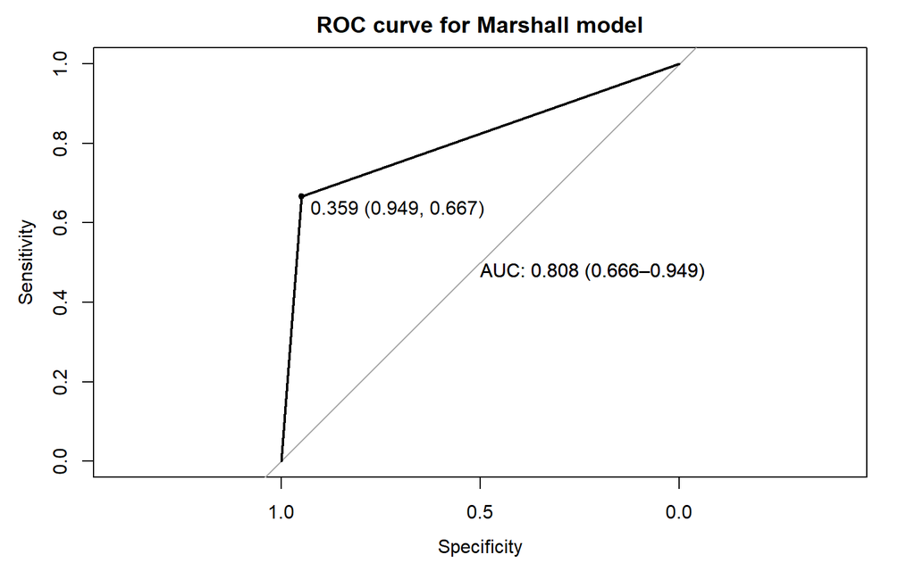

# Rotterdam score (Maas et al., 2005)

Similarly to Marshall’s score, Rotterdam score was developed based on CT findings. It included midline shift and basal cisterns effacement, but did not include mass lesions > 25 cc or mass evacuation. In addition, it included the presence of EDH, SAH and IVH.

### Distribution of Rotterdam score by outcome

[figure not shown]

In this cohort all survivors had a Rotterdam score lower than 4.  
A score of 3 was associated with 16% mortality (Mass 2005) but in our cohort 5.5% of those who had a Rotterdam score of 3 died.

### Mortality rate by Rotterdam score

[output not shown]

Higher scores were more rare in our cohort but seem highly indicative of poor outcome- only 8% had a score greater than 3, and they all died. Survival rates of older adults with a Rotterdam score of 4 or more should be investigated in a larger cohort with an adequate number of moderate-severe injuries.

## Predicted vs. actual 6-month mortality

### Confusion matrix for Rotterdam score cut-off >3

Prognosis by Rotterdam score >3 vs. Actual outcome

|  | Expired | Survived |
| --- | --- | --- |
| <=3 | 5 | 78 |
| >3 | 7 | 0 |

<sup>a</sup> Balanced accuracy: 79%, Sensitivity: 58%, Specificity: 100%

### Confusion matrix for Rotterdam score cut-off >2

A lower threshold yields better sensitivity but poorer overall performance:  
Sensitivity 83%, specificity: 33%, balanced accuracy = 58%.  
Overall accuracy was 40%.

|  | Expired | Survived |
| --- | --- | --- |
| <=2 | 2 | 26 |
| >2 | 10 | 52 |

<sup>a</sup> Balanced accuracy: 58%, Sensitivity: 83%, Specificity: 33%

## Discrimination

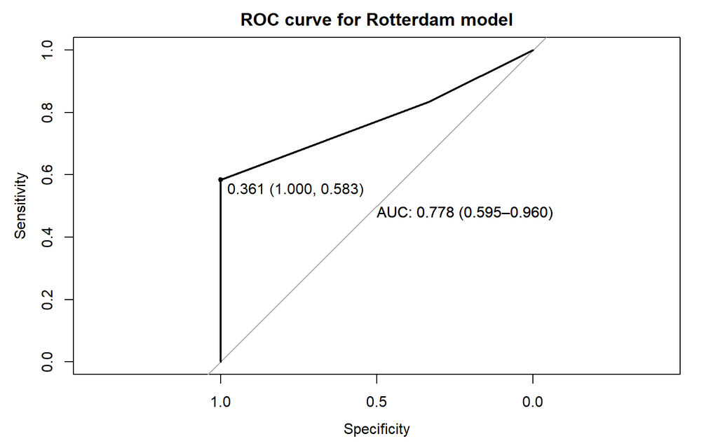

AUC= 0.78 (95% CI: 0.60-0.96)  
Sensitivity= 58% Specificity= 100%

# IMPACT Model (Steyerberg et al, 2008)

The IMPACT database includes data from 11 studies, with a total of 8,509 participants with severe-moderate TBI, aged 14+ (median age= 32, IQR=21-45).  
3 models were suggested:  
1. Core model- age, GCS motor score and pupil reaction to light.  
2. Extended model- Core model + CT findings (Marshall score, tSAH, EDH) + hypoxia + hypotension at arrival to ED.  
3. Lab model - extended model + blood glucose + blood hemoglobin in ED.

IMPACT models were implemented according to the published coefficients and also by a score chart.

## Logistic regression

The correlation of IMPACT models to the 6-month mortality outcome in the Geri cohort was tested using logistic regression models.

|  |  |  |  | 6-month mortality |  |  |  |  |  |
| --- | --- | --- | --- | --- | --- | --- | --- | --- | --- |
| Predictors | Odds Ratios | CI | p | Odds Ratios | CI | p | Odds Ratios | CI | p |
| (Intercept) | 0.20 | 0.08 – 0.43 | **<0.001** | 0.44 | 0.19 – 1.06 | 0.062 | 2.38 | 0.55 – 13.56 | 0.281 |
| ImpactCoreModel | 1.83 | 0.36 – 7.63 | 0.415 |  |  |  |  |  |  |
| ImpactExtendedModel |  |  |  | 5.54 | 1.92 – 18.81 | **0.003** |  |  |  |
| ImpactLabModel |  |  |  |  |  |  | 9.86 | 3.02 – 47.55 | **0.001** |
| Observations | 90 |  |  | 90 |  |  | 90 |  |  |
| R<sup>2</sup> Tjur | 0.010 |  |  | 0.144 |  |  | 0.259 |  |  |

## Discrimination

IMPACT models’ performance was evaluated and compared using ROC curves.

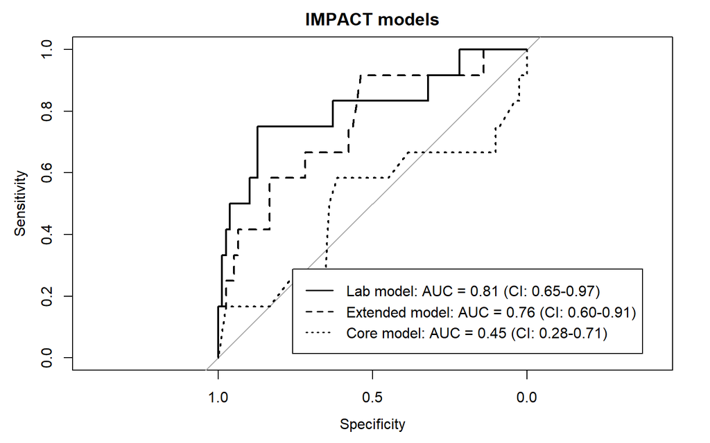

Best AUC was obtained by the IMPACT Lab model (AUC=0.81, 95% CI: 0.65-0.97).  
Sensitivity= 0.75, Specificity= 0.87.  
IMPACT extended achieved an AUC of 0.76 (95% CI: 0.60-0.91). As expected, IMPACT core’s AUC was 0.45 (95% CI: 0.28-0.71), worse than a coin flip. To test for differences between IMPACT models’ performance, pairwise comparisons of AUCs of the 3 models were performed using DeLong’s test for two correlated ROC curves. IMPACT lab model had a statistically significant difference from the IMPACT core model (p-value=0.023), but no statistically significant difference was found between the extended model and the core model (p-value=0.23) or the lab model (p-value=0.078). It should be remembered that due to the small sample size the confidence intervals for the AUCs are very wide and the ability to detect statistically significant differences is very limited.

## Summary

Marshall’s score had an AUC of 0.81 (95% CI: 0.67-0.96), Rotterdam score had an AUC of 0.78 (95% CI: 0.60-0.96) and IMPACT lab model had an AUC of 0.81 (CI: 0.65-0.97).  
No statistically significant differences were found between models’ AUCs, except for IMPACT core model which was significantly worse than IMPAT lab and had no statistically significant correlation to 6-month mortality (p-value=0.415). Marshall’s classification and Rotterdam’s score have an accepted cut-off, which has a sensitivity of 67% and 58% respectively, which is low.

# 6-month mortality predictors

## CT findings

|  | Expired (N=12) | Survived (N=78) | P-value | OR (95% CI) |
| --- | --- | --- | --- | --- |
| Lesion size > 25cc | 2 (16.7%) | 0 (0%) | 0.023 | 297813686.4 (0 - Inf) |
| Evacuated hematoma | 3 (25.0%) | 1 (1.3%) | 0.007 | 25.7 (2.4 - 273.5) |
| Basal cisterns effacement (partial or full) | 6 (50.0%) | 2 (2.6%) | <0.001 | 38 (6.3 - 230.6) |
| Midline shift > 5mm | 7 (58.3%) | 2 (2.6%) | <0.001 | 53.2 (8.7 - 326.2) |
| Shear | 6 (50.0%) | 11 (14.1%) | 0.009 | 6.1 (1.7 - 22.3) |
| Edema | 4 (33.3%) | 2 (2.6%) | 0.002 | 19 (3 - 120.5) |
| Contusion | 8 (66.7%) | 18 (23.1%) | 0.004 | 6.7 (1.8 - 24.7) |
| Skull fracture | 7 (58.3%) | 12 (15.4%) | 0.003 | 7.7 (2.1 - 28.3) |
| Subdural hematoma | 11 (91.7%) | 46 (59.0%) | 0.05 | 7.7 (0.9 - 62.3) |
| Epidural hematoma | 2 (16.7%) | 3 (3.8%) | 0.13 | 5 (0.7 - 33.7) |
| Subarachnoid hematoma | 10 (83.3%) | 49 (62.8%) | 0.206 | 3 (0.6 - 14.5) |
| Intraventricular hematoma | 4 (33.3%) | 9 (11.5%) | 0.068 | 3.8 (1 - 15.3) |

Basal cisterns effacement, midline shift, shear, edema, contusion and skull fracture were significantly correlated to 6-month mortality. Hemorrhagic findings that are used in most prediction models- EDH, SAH, and IVH did not show a statistically significant correlation. SDH was nearly significant.

## Clinical and lab characteristics

|  | Expired (N=12) | Survived (N=78) | P-value | OR (95% CI) |
| --- | --- | --- | --- | --- |
| Age |  |  | 0.395 | 1 (0.9 - 1) |
| Mean (SD) | 75 (± 7.6) | 77 (± 7.5) |  |  |
| ED GCS motor |  |  | 0.166 | 0.3 (0 - 11.9) |
| 1-No Response | 1 (8.3%) | 1 (1.3%) |  |  |
| 4-Flexion Withdrawal | 1 (8.3%) | 3 (3.8%) |  |  |
| 5-Localizes to Pain | 1 (8.3%) | 4 (5.1%) |  |  |
| 6-Obeys Commands | 9 (75.0%) | 70 (89.7%) |  |  |
| ED pupil reactivity |  |  | 0.126 | 43759377.7 (0 - Inf) |
| Bilateral | 10 (83.3%) | 76 (97.4%) |  |  |
| Unilateral | 1 (8.3%) | 0 (0%) |  |  |
| Missing | 1 (8.3%) | 2 (2.6%) |  |  |
| ED arrival hypotension |  |  | 1 | 0 (0 - Inf) |
| No | 10 (83.3%) | 68 (87.2%) |  |  |
| Yes | 0 (0%) | 3 (3.8%) |  |  |
| Missing | 2 (16.7%) | 7 (9.0%) |  |  |
| ED glucose (mg/dL) |  |  | 0.004 | 1 (1 - 1) |
| Mean (SD) | 160 (± 51) | 130 (± 31) |  |  |
| Missing | 0 (0%) | 4 (5.1%) |  |  |
| ED Hemoglobin (mg/dL) |  |  | 0.538 | 0.9 (0.6 - 1.3) |
| Mean (SD) | 13 (± 1.9) | 13 (± 1.7) |  |  |
| Missing | 0 (0%) | 3 (3.8%) |  |  |

## Predictors’ odds ratio plot

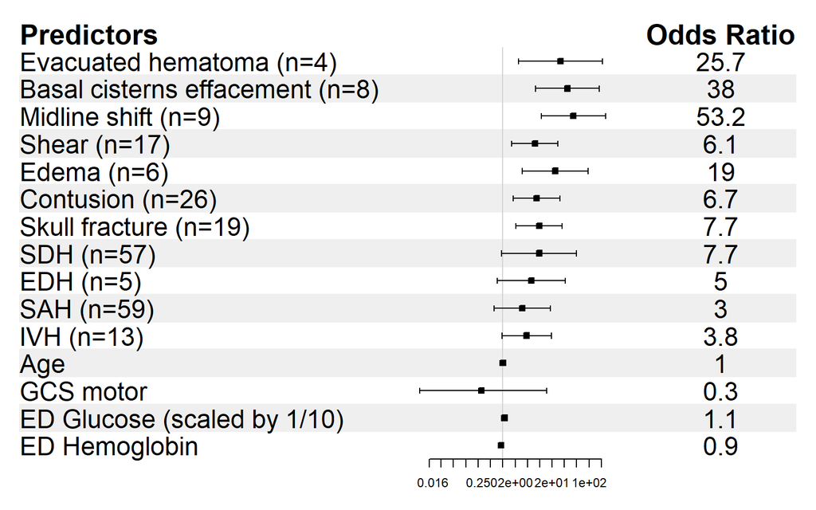

# Other predictors

To explore possible correlates of mortality, sample’s characteristics were described by 6-month mortality outcome.

## Demographic and pre-injury clinical characteristics

|  | Expired (N=12) | Survived (N=78) | P-value |
| --- | --- | --- | --- |
| Age |  |  | 0.395 |
| Mean (SD) | 75 (± 7.6) | 77 (± 7.5) |  |
| Sex |  |  | 0.369 |
| Female | 5 (41.7%) | 44 (56.4%) |  |
| Male | 7 (58.3%) | 34 (43.6%) |  |
| Race |  |  | 1 |
| Other | 1 (8.3%) | 6 (7.7%) |  |
| White | 11 (91.7%) | 67 (85.9%) |  |
| Black | 0 (0%) | 4 (5.1%) |  |
| Missing | 0 (0%) | 1 (1.3%) |  |
| Years of education |  |  | 0.009 |
| Mean (SD) | 17 (± 3.2) | 15 (± 2.7) |  |
| Missing | 2 (16.7%) | 5 (6.4%) |  |
| Employment status |  |  | 0.746 |
| Retired | 7 (58.3%) | 57 (73.1%) |  |
| Employed | 2 (16.7%) | 13 (16.7%) |  |
| Disabled | 0 (0%) | 2 (2.6%) |  |
| Missing | 3 (25.0%) | 6 (7.7%) |  |
| Marital status |  |  | 0.075 |
| Married | 5 (41.7%) | 35 (44.9%) |  |
| Widowed | 3 (25.0%) | 19 (24.4%) |  |
| Divorced | 0 (0%) | 16 (20.5%) |  |
| Never married | 3 (25.0%) | 5 (6.4%) |  |
| Missing | 1 (8.3%) | 3 (3.8%) |  |
| Living situation |  |  | 0.701 |
| Independent- lives alone | 5 (41.7%) | 23 (29.5%) |  |
| Independent- lives with others | 7 (58.3%) | 48 (61.5%) |  |
| Other | 0 (0%) | 1 (1.3%) |  |
| Sub-acute/SNF | 0 (0%) | 2 (2.6%) |  |
| Missing | 0 (0%) | 4 (5.1%) |  |
| Engaged in regularly scheduled activities | 4 (33.3%) | 23 (29.5%) | 0.469 |
| Health Insurance |  |  | 0.737 |
| Private insurance | 3 (25.0%) | 27 (34.6%) |  |
| Medicare/Medicaid | 9 (75.0%) | 47 (60.3%) |  |
| Unknown | 0 (0%) | 4 (5.1%) |  |
| Alcohol Use Disorder Identification Test (range 0-12 (worst)) |  |  | 0.225 |
| Mean (SD) | 2.2 (± 2.7) | 1.4 (± 1.8) |  |
| Missing | 0 (0%) | 5 (6.4%) |  |
| History of tobacco use | 4 (33.3%) | 26 (33.3%) | 0.693 |
| Total years smoked |  |  | 0.523 |
| Mean (SD) | 13 (± 6.4) | 18 (± 16) |  |
| Missing | 8 (66.7%) | 55 (70.5%) |  |
| Current tobacco use | 0 (0%) | 4 (5.1%) | 1 |
| Pre-injury cognitive status |  |  | 0.348 |
| MCI/dementia | 7 (58.3%) | 32 (41.0%) |  |
| Normal | 4 (33.3%) | 36 (46.2%) |  |
| Missing | 1 (8.3%) | 10 (12.8%) |  |
| FAQ (Functional Activities Questionnaire, range 0-30 (worst)) |  |  | 0.572 |
| Mean (SD) | 7.4 (± 11) | 5.2 (± 10) |  |
| Missing | 4 (33.3%) | 16 (20.5%) |  |
| Average daily number of blocks walked per day |  |  | 0.174 |
| Mean (SD) | 15 (± 14) | 9.1 (± 12) |  |
| Missing | 2 (16.7%) | 4 (5.1%) |  |
| Groningen Frailty Indicator (GFI, range 0-15 (worst)) |  |  | 0.427 |
| Mean (SD) | 5.0 (± 3.4) | 4.2 (± 2.8) |  |
| Missing | 4 (33.3%) | 18 (23.1%) |  |
| Frailty status (GFI) |  |  | 0.707 |
| Frail (>4 total score) | 3 (25.0%) | 19 (24.4%) |  |
| Not frail (<4) | 5 (41.7%) | 41 (52.6%) |  |
| Missing | 4 (33.3%) | 18 (23.1%) |  |
| NPI-Q (Neuropsychiatric Inventory questionnaire, range 0-36 (worst)) |  |  | 0.339 |
| Mean (SD) | 1.8 (± 1.7) | 3.5 (± 4.0) |  |
| Missing | 6 (50.0%) | 48 (61.5%) |  |
| ECog12 (Everyday Cognition-12, range 1-4 (worst)) |  |  | 0.13 |
| Mean (SD) | 1.1 (± 0.14) | 1.4 (± 0.72) |  |
| Missing | 3 (25.0%) | 23 (29.5%) |  |

## Medical history

|  | Expired (N=12) | Survived (N=78) | P-value |
| --- | --- | --- | --- |
| Number of pre-existing medical conditions |  |  | 0.797 |
| Mean (SD) | 3.75 (1.96) | 3.94 (2.36) |  |
| Median [Min, Max] | 4.00 [1.00, 8.00] | 4.00 [0, 12.0] |  |
| Missing | 0 (0%) | 1 (1.3%) |  |
| Charlson Comorbidity Index (range 2-37 (worst)) |  |  | 0.382 |
| Mean (SD) | 4.63 (1.41) | 4.15 (1.46) |  |
| Median [Min, Max] | 4.50 [3.00, 7.00] | 4.00 [2.00, 8.00] |  |
| Missing | 4 (33.3%) | 10 (12.8%) |  |
| Number of pre-injury medications |  |  | 0.971 |
| Mean (SD) | 11.6 (7.81) | 11.5 (6.36) |  |
| Median [Min, Max] | 10.0 [1.00, 22.0] | 10.0 [1.00, 22.0] |  |
| Missing | 0 (0%) | 9 (11.5%) |  |
| CAD | 1 (8.3%) | 11 (14.1%) | 1 |
| Atrial fibrillation | 2 (16.7%) | 21 (26.9%) | 0.724 |
| Valvular disease | 0 (0%) | 3 (3.8%) | 1 |
| Congestive Heart Failure | 0 (0%) | 5 (6.4%) | 1 |
| Pacemaker | 1 (8.3%) | 2 (2.6%) | 0.305 |
| Other cardiac condition | 4 (33.3%) | 17 (21.8%) | 0.467 |
| Cerebrovascular Disease | 2 (16.7%) | 8 (10.3%) | 0.619 |
| Parkinson's Disease | 1 (8.3%) | 0 (0%) | 0.135 |
| Alzheimer's Disease | 2 (16.7%) | 3 (3.8%) | 0.069 |
| Headache | 0 (0%) | 11 (14.1%) | 0.348 |
| Diabetes (type I and II) | 4 (33.3%) | 16 (20.5%) | 0.456 |
| Hypertension | 8 (66.7%) | 52 (66.7%) | 1 |
| Hypercholesterolemia | 2 (16.7%) | 27 (34.6%) | 0.323 |
| B12 Deficiency | 2 (16.7%) | 2 (2.6%) | 0.06 |
| Thyroid disease | 1 (8.3%) | 15 (19.2%) | 0.686 |
| Urinary incontinence | 1 (8.3%) | 13 (16.7%) | 1 |
| Sleep apnea | 1 (8.3%) | 12 (15.4%) | 1 |
| REM Sleep Behavior Disorder | 0 (0%) | 3 (3.8%) | 1 |
| Chronic Kidney Disease | 1 (8.3%) | 5 (6.4%) | 0.526 |
| Chronic Lung Disease | 1 (8.3%) | 12 (15.4%) | 1 |
| Arthritis | 3 (25.0%) | 31 (39.7%) | 0.36 |
| Psychiatric clinic consultation | 1 (8.3%) | 16 (20.5%) | 0.679 |
| Psychiatric hospital | 0 (0%) | 5 (6.4%) | 1 |
| Psychiatric medication | 3 (25.0%) | 18 (23.1%) | 0.684 |
| Anxiety | 2 (16.7%) | 9 (11.5%) | 0.64 |
| Depression | 4 (33.3%) | 10 (12.8%) | 0.091 |
| Other psychiatric disorder | 1 (8.3%) | 5 (6.4%) | 1 |
| Developmental condition | 1 (8.3%) | 4 (5.1%) | 0.524 |
| Anticoagulants | 3 (25.0%) | 16 (20.5%) | 0.72 |
| Platelet aggregation inhibitors | 3 (25.0%) | 21 (26.9%) | 1 |
| AD, dementia or PD of relative |  |  | 1 |
| Alzheimer's Disease | 1 (8.3%) | 10 (12.8%) |  |
| Other Dementia | 1 (8.3%) | 6 (7.7%) |  |
| Parkinson's Disease | 0 (0%) | 5 (6.4%) |  |
| Missing | 10 (83.3%) | 57 (73.1%) |  |
| Relative with AD, dementia or PD |  |  | 1 |
| Child | 0 (0%) | 2 (2.6%) |  |
| Parent | 2 (16.7%) | 17 (21.8%) |  |
| Sibling | 0 (0%) | 3 (3.8%) |  |
| Missing | 10 (83.3%) | 56 (71.8%) |  |
| AD, dementia or PD early onset in relative | 0 (0%) | 3 (3.8%) | 1 |

Medical conditions and comorbidity in general were the same for those who expired and those who survived.

## Injury and clinical characteristics

|  | Expired (N=12) | Survived (N=78) | P-value |
| --- | --- | --- | --- |
| Glasgow Comma Scale (GCS) |  |  | 0.019 |
| 15 | 3 (25.0%) | 48 (61.5%) |  |
| 14 | 6 (50.0%) | 18 (23.1%) |  |
| 13 | 0 (0%) | 6 (7.7%) |  |
| <13 | 3 (25.0%) | 6 (7.7%) |  |
| TBI severity by GCS |  |  | 0.009 |
| Mild | 9 (75.0%) | 72 (92.3%) |  |
| Moderate | 0 (0%) | 5 (6.4%) |  |
| Severe | 3 (25.0%) | 1 (1.3%) |  |
| ED GCS motor |  |  | 0.166 |
| 1-No Response | 1 (8.3%) | 1 (1.3%) |  |
| 4-Flexion Withdrawal | 1 (8.3%) | 3 (3.8%) |  |
| 5-Localizes to Pain | 1 (8.3%) | 4 (5.1%) |  |
| 6-Obeys Commands | 9 (75.0%) | 70 (89.7%) |  |
| ED pupil reactivity |  |  | 0.126 |
| Bilateral | 10 (83.3%) | 76 (97.4%) |  |
| Unilateral | 1 (8.3%) | 0 (0%) |  |
| Missing | 1 (8.3%) | 2 (2.6%) |  |
| LOC - Loss of Consciousness |  |  | 0.765 |
| No | 5 (41.7%) | 36 (46.2%) |  |
| Yes | 7 (58.3%) | 40 (51.3%) |  |
| Missing | 0 (0%) | 2 (2.6%) |  |
| PTA - Post-traumatic Amnesia |  |  | 0.535 |
| No | 4 (33.3%) | 36 (46.2%) |  |
| Yes | 8 (66.7%) | 40 (51.3%) |  |
| Missing | 0 (0%) | 2 (2.6%) |  |
| ACRM+ |  |  | 0.722 |
| No | 2 (16.7%) | 20 (25.6%) |  |
| Yes | 10 (83.3%) | 56 (71.8%) |  |
| Missing | 0 (0%) | 2 (2.6%) |  |
| ACRM- and CT+ | 2 (16.7%) | 20 (25.6%) | 0.722 |
| ACRM+ and CT- | 10 (83.3%) | 56 (71.8%) | 0.722 |
| Prior TBI |  |  | 0.758 |
| PTA only | 0 (0%) | 2 (2.6%) |  |
| LOC +/- PTA | 1 (8.3%) | 13 (16.7%) |  |
| No prior TBI | 10 (83.3%) | 59 (75.6%) |  |
| Missing | 1 (8.3%) | 4 (5.1%) |  |
| Prior TBI frequency |  |  | 0.758 |
| None | 10 (83.3%) | 59 (75.6%) |  |
| 1 | 1 (8.3%) | 13 (16.7%) |  |
| > 1 | 0 (0%) | 2 (2.6%) |  |
| Missing | 1 (8.3%) | 4 (5.1%) |  |
| Anticoagulant reversal in ED |  |  | 0.009 |
| No | 7 (58.3%) | 71 (91.0%) |  |
| Yes | 5 (41.7%) | 7 (9.0%) |  |
| Injury mechanism |  |  | 0.514 |
| Ground level fall | 6 (50.0%) | 48 (61.5%) |  |
| Fall from height | 3 (25.0%) | 14 (17.9%) |  |
| Motor vehicle accident | 1 (8.3%) | 10 (12.8%) |  |
| Assault | 1 (8.3%) | 2 (2.6%) |  |
| Other | 1 (8.3%) | 4 (5.1%) |  |
| External injury (AIS>=2) |  |  | 0.391 |
| No | 1 (8.3%) | 24 (30.8%) |  |
| Yes | 5 (41.7%) | 34 (43.6%) |  |
| Missing | 6 (50.0%) | 20 (25.6%) |  |
| ED glucose (mg/dL) |  |  | 0.004 |
| Mean (SD) | 160 (± 51) | 130 (± 31) |  |
| Missing | 0 (0%) | 4 (5.1%) |  |
| ED Hemoglobin (mg/dL) |  |  | 0.538 |
| Mean (SD) | 13 (± 1.9) | 13 (± 1.7) |  |
| Missing | 0 (0%) | 3 (3.8%) |  |
| ED arrival hypotension |  |  | 1 |
| No | 10 (83.3%) | 68 (87.2%) |  |
| Yes | 0 (0%) | 3 (3.8%) |  |
| Missing | 2 (16.7%) | 7 (9.0%) |  |
| ED arrival hypoxia |  |  | 0.273 |
| No | 2 (16.7%) | 8 (10.3%) |  |
| Yes | 1 (8.3%) | 0 (0%) |  |
| Missing | 9 (75.0%) | 70 (89.7%) |  |

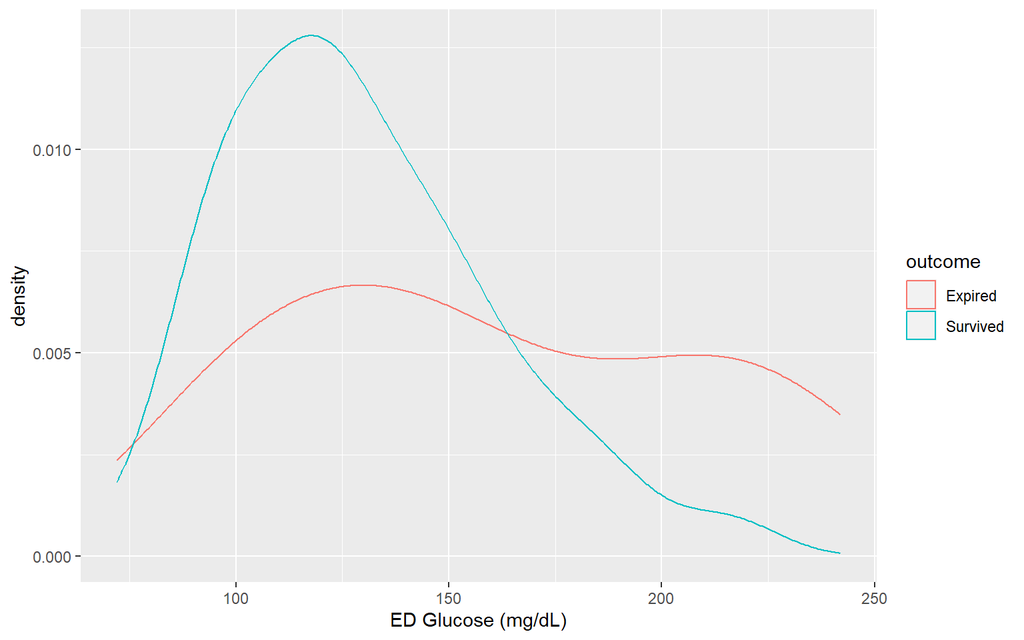